# Visualisation and statistical analysis

Michael Dunn, Dept. of Linguistics and Philology, Uppsala University

Session 3, 2018-10-08

Topics

- Homework
  - writing a function
  - importing the Kelly data
- Getting the parts of your data you are interested in:
  - filter()
  - select()
- Sorting, renaming, and mutating (adding)
- Plotting simple tabular data
- Distributions and histograms
  - rnorm
  - runif
- log values
- Zipf distribution

## House buying

`r`r a <- 1 b <- NA is.na(a)

```
[1] FALSE
```

`r`r is.na(b)

```
[1] TRUE
```

`r`r monthly.cost <- function(cost, fee, operating=NA, deposit=NA, interest=0.017, amortization=0.02, n.residents=2){ if (is.na(deposit)){ deposit <- cost * 0.15} if (is.na(operating)) {operating <- 300 * n.residents} loan <- cost - deposit interest <- (loan * (interest + amortization)) / 12 interest + fee + operating } monthly.cost(4490000, 4695, 17400/12)

```
[1] 17913
```

`r`r monthly.cost(2970000, 3210)

```
[1] 11594
```

# Tidyverse vs. base R

- The read_csv is the tidyverse version of read.csv.
- We’re working in the tidyverse `library(tidyverse)` at the beginning of every script!

`r`r # Base R m <- matrix(1:9, nrow=3) m # a matrix

```
     [,1] [,2] [,3]
[1,]    1    4    7
[2,]    2    5    8
[3,]    3    6    9
```

`r`r m[1,1] # a cell

```
[1] 1
```

`r`r class(m[1,]) # a vector

[output not shown]

`r`r m[1,1] # a cell

```
[1] 1
```

`r`r m[1,] # a vector

```
[1] 1 4 7
```

## Preliminaries

- Please install the `babynames` package. All loading this package does is give you one big tibble called `babynames` with some interesting sample data for us to play with
- To install the package use RStudio “Tools” -> “Install packages…”

It’s good style to do all your library function calls at the beginning of your scripts, notebooks, etc. For example, tidyverse redefines `filter`, and you don’t want `filter` to mean one thing for one half of your script and something else for the other. It also means that if you cut-and-paste something you know where to look for any libraries it might depend on.

`r`r library(tidyverse) library(babynames)

- loading babynames gives you access to a huge tibble (table of text and numerical data) called `babynames`
- You can enter `help(babynames)` in the console to get a description of the data (SSA is the US Social Security Administration). Next week we’ll look at Swedish names instead!

Long data: every observation is its own row. Next week we’ll look at Swedish name data from Statistiska Centralbyrån, which is in “wide” format (multiple observations per row)

`r`r head(babynames)

| year | sex | name | n | prop |
| --- | --- | --- | --- | --- |
| 1880 | F | Mary | 7065 | 0.07238 |
| 1880 | F | Anna | 2604 | 0.02668 |
| 1880 | F | Emma | 2003 | 0.02052 |
| 1880 | F | Elizabeth | 1939 | 0.01987 |
| 1880 | F | Minnie | 1746 | 0.01789 |
| 1880 | F | Margaret | 1578 | 0.01617 |

## First steps with dplyr (part of tidyverse)

Dplyr aims to provide a function for each basic verb of data manipulation. These include:

```
- filter() to select cases based on their values.
- arrange() to reorder the cases.
- select() and rename() to select variables based on their names.
- mutate() and transmute() to add new variables that are functions of existing variables.
```

The dplyr verbs: filter, select:

Filtering rows:

| year | sex | name | n | prop |
| --- | --- | --- | --- | --- |
| 1897 | F | Michael | 7 | 0.00002819 |
| 1906 | F | Michael | 5 | 0.00001595 |
| 1909 | F | Michael | 7 | 0.00001902 |
| 1910 | F | Michael | 9 | 0.00002145 |
| 1911 | F | Michael | 7 | 0.00001584 |
| 1912 | F | Michael | 8 | 0.00001364 |
| 1913 | F | Michael | 12 | 0.00001832 |
| 1914 | F | Michael | 16 | 0.00002009 |
| 1915 | F | Michael | 14 | 0.00001367 |
| 1916 | F | Michael | 18 | 0.00001658 |

[output cut: 99 more lines]

| year | sex | name | n | prop |
| --- | --- | --- | --- | --- |
| 2000 | F | Lena | 473 | 0.0002372 |

Use | for “or”

| year | sex | name | n | prop |
| --- | --- | --- | --- | --- |
| 1960 | F | Rima | 20 | 0.000009616 |
| 1961 | F | Rima | 13 | 0.000006261 |
| 1961 | F | Maja | 6 | 0.000002890 |
| 1962 | F | Rima | 12 | 0.000005920 |
| 1963 | F | Rima | 12 | 0.000006037 |
| 1963 | F | Maja | 6 | 0.000003018 |
| 1964 | F | Rima | 14 | 0.000007153 |
| 1964 | F | Maja | 6 | 0.000003066 |
| 1965 | F | Rima | 23 | 0.000012587 |
| 1965 | F | Maja | 7 | 0.000003831 |

- `filter(a, b)` is the same as the “and” relationship `filter(a & b)`; cf. “or” `filter(a | b)`

| year | sex | name | n | prop |
| --- | --- | --- | --- | --- |
| 1880 | F | Anastasia | 10 | 0.000102455 |
| 1881 | F | Anastasia | 11 | 0.000111274 |
| 1882 | F | Anastasia | 11 | 0.000095077 |
| 1883 | F | Anastasia | 14 | 0.000116609 |
| 1884 | F | Anastasia | 17 | 0.000123559 |
| 1885 | F | Anastasia | 15 | 0.000105672 |
| 1886 | F | Anastasia | 23 | 0.000149607 |
| 1886 | M | Xavier | 5 | 0.000042002 |
| 1887 | F | Anastasia | 22 | 0.000141550 |
| 1888 | F | Anastasia | 20 | 0.000105570 |

[output cut: 289 more lines]

Selecting columns:

`r`r select(babynames, year, name, n)

| year | name | n |
| --- | --- | --- |
| 1880 | Mary | 7065 |
| 1880 | Anna | 2604 |
| 1880 | Emma | 2003 |
| 1880 | Elizabeth | 1939 |
| 1880 | Minnie | 1746 |
| 1880 | Margaret | 1578 |
| 1880 | Ida | 1472 |
| 1880 | Alice | 1414 |
| 1880 | Bertha | 1320 |
| 1880 | Sarah | 1288 |

[output cut: 990 more lines]

## Piping %>%

`funct(a, b)` is the same as `a %>% funct(b)`

This can simplify things:

| year | sex | name | n | prop |
| --- | --- | --- | --- | --- |
| 1897 | F | Michael | 7 | 0.00002819 |

http://r4ds.had.co.nz/pipes.html

Functions are verbs, arguments are nouns

How to deal with multiple steps of an analysis

- save intermediate steps (clutters the namespace, lots of memory)
- overwrite the original (hard to debug)
- nested functions (have to read in inside-out order, arguments are spread out)
- the pipe syntax (the human way!)
- piped functions can be chained together:

Works best

- with one input, one output
- not too many steps (<10)
- Notice the return value of the pipe: `a %>% b` “sends” a to b, and then the statement returns something, which can be sent along to the next thing `a %>% b %>% c`
- The thing that you’re piping in is the first, default argument of the function. Tidyverse functions mark this in the help files with a leading dot, e.g. `.data` in `help(filter)`
- Chaining pipes together
- **TODO** Class time to experiment

### Assigning piped data

The final results of pipes can be assigned to variables as normal of course

There’s also a right arrow `->` version of the assignment operator `<-`

`r`r x <- 4 # is the same as 4 -> x

- This is convenient on the console sometimes, when you want to reuse something from your history and assign it to a variable
- It’s generally discouraged otherwise
- But it does make nice logical sense with pipe-sequences

```
data %>% a() %>% b() -> result
```

Compare the “normal” way:

```
result <- data %>% a() %>% b()
```

### sorting columns with arrange

`desc` means descending

### Renaming columns

[figure not shown]

`r`r # geom_col() # geom_line()

### mutate() adds columns

[figure not shown]

Dot “.” stands for “the thing that you’re piping in” (for cases when it’s not the first argument)

[figure not shown]

cf. also `.data` in docs (see e.g. `help(filter)`)

## ggplot

- Calling the function `ggplot` starts assembling the graph; it has the default argument `data`, which you can pipe to the function
- the `aes()` (“aesthetic”) function maps data onto graph attributes
- You build up the plot in layers using `+`
- geometic layers have names starting with `geom_`. These include `geom_point` (scatterplots), `geom_box` (boxplots), `geom_histogram` (histograms)`, and may others. There is a default set that it part of tidyverse, and then others can be added by calling libraries.
- There are lots more things you can change, but these three steps are the basic idea: take data, map to an aesthetic, and plot as a geometric layer

Numbers like 1.5e-05 are scientific notation, shorthand for “1.5 times 10 to the power of -5”, which means 0.000015

`r`r library(tidyverse) # should do this at the beginning my.data <- tibble(values=rnorm(100, 10, 2.5)) my.data %>% ggplot(aes(x=values)) + geom_histogram(binwidth=1)

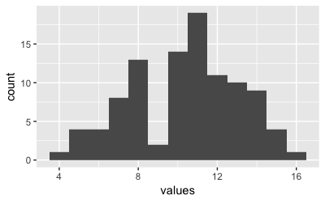

`r`r tibble(values=rnorm(10000, 10, 2.5)) %>% ggplot(aes(x=values)) + geom_histogram(binwidth=1)

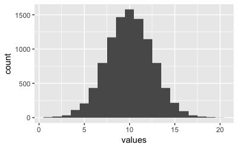

[figure not shown]

| rank | freq |
| --- | --- |
| 1 | 1.0000 |
| 2 | 0.5000 |
| 3 | 0.3333 |
| 4 | 0.2500 |
| 5 | 0.2000 |
| 6 | 0.1667 |
| 7 | 0.1429 |
| 8 | 0.1250 |
| 9 | 0.1111 |
| 10 | 0.1000 |

# Some statistical distributions

## Normal distribution

Galton Board

[video not shown]

In a normal distribution: - 68.2% of values within one standard deviation - 95.4% within two standard deviations - 99.7% within 3 - 99.99% within 4

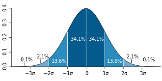

Standard deviations

Normal distributions can be described by two parameters, mean and standard deviation. The `rnorm()` function generates vectors of random numbers accordingn to a normal distribution.

**TODO** Read the help for the `rnorm()` function. Generate some vectors of normally distributed random numbers given different means and standard deviations.

## Histogram

- rnorm(N, mean, sd)

`r`r toy.data %>% ggplot(aes(x=rank, y=freq)) + geom_point()

[figure not shown]

`r`r toy.data %>% ggplot(aes(x=log10(rank), y=log10(freq))) + geom_point() + geom_line()

[figure not shown]

## Uniform distribution

There are many kinds of distributions.

- runif(N, min, max)

In the *Uniform distribution* there is an equal chance of getting any value between the minimum and the maximum